# ECON 491: Analyzing Chicago Home Prices With Machine Learning

By: Zayn Khan (zaynk2), Manan Jain (mananj2), Neil Kasbekar (neilnk2), Armaan Bajpai, (abajpai2)

# Abstract

The United States estate market size was estimated at USD 3.69 trillion in 2021 and is expected to reach USD 3.81 trillion in 2022 (Shaikh, 2011). The need to accurately estimate the value of a house for sale and for prediction of future sales is felt by real estate brokers and policymakers alike. Especially in light of a longstanding history of potentially biased methods by the entities of the American home appraisal industry, accurate house evaluation methods are a research area to be expanded upon in economic research. Given the vast variety of covariates that influence the price of a home, practicing methods of machine learning, regularization methods – notably Ridge and LASSO– and generate conclusions is a relevant, marketable job skill to create efficiency in an increasingly automated world. In addition, incorporating data reflective of factors of environmental degradation, crime rates, demographics, and housing quality, we can make more complex valuations that will play an increasingly important factor for housing prices considering the route of climate change. Ultimately, we sought to answer what economic indicators and real-estate information best predicts the value of a piece of real estate in Chicago, and if we can predict the price of a house in based off of this information.

# Package Explanation

For our project we chose to use Python via a Jupyter Notebook. The packages we used contain classical machine learning methods from the SKLearn Library. These perform the machine learning much the same as the packages do in R. We chose Pandas & Geopandas to create our dataframes from our input data, and the feature and model selection packages from SKLearn to help us see the error

# Literature Review

- US Census SF1: geographic codes, area, race/ethnicity, household type, housing tenure and average household size
- US Census SF3: geographic codes, area, school enrolment, educational attainment, labor force, occupation, income, occupied housing units and housing unit value
- CalEnviroScreen 2.0: geographic codes, area, ozone concentration, diesel particulate matter (PM) emissions, drinking water contaminant index, and pesticide used in production-agriculture per square mile of the census tract

Previous studies in this area have had issues like specification error (Peterson & Flanagan, 2009), overfitting, and appropriate model selections (Bork & Møller, 2018), so investigating the large number of determinants of owner-occupied housing values in census tracts of California by using hedonic regression-based parametric learning methods would seemingly advance prediction accuracy. To replicate this strategy for housing value in Chicago, we gathered data from multiple sources to gather as much context about an area a house is in. Pulling from the Cook County Open Data Portal, we have a dataset for the residential modeling characteristics for the city of Chicago. This includes a variety of information on homes sold in the City of Chicago. A full list is included but the most important variables we wanted were:

- Sale Price
- Square Footage of Land
- Square Footage of Home
- Tract Median Income
- Number of Rooms
- Number of Bedrooms
- Census Tract Geoid (as a value for location)

- Property Index Number
- Property Class
- Township Name
- Number of Active 288s (HIEs)
- Number of Ended 288s (HIEs)
- Sale Price
- Land Square Feet
- Large Home Indicator
- Age
- Apartments
- Wall Material
- Roof Material
- Rooms
- Bedrooms
- Basement
- Basement Finish
- Central Heating
- Central Air Conditioning
- Fireplaces
- Attic Type
- Full Baths
- Half Baths
- Cathedral Ceiling
- Garage 1 Size
- Garage 1 Material
- Garage 1 Attached
- Garage 1 Area
- Building Square Feet
- Repair Condition
- Attic Finish
- Renovation
- Porch
- Tract GEOID
- O'Hare Noise Indicator
- FEMA Floodplain
- Flood Risk Factor
- Flood Risk Direction
- Road Proximity < 100 Feet
- Road Proximity 101 - 300 Feet
- Elementary/Middle School District
- High School District
- Longitude
- Latitude
- Tax Rate
- Tract Median Income
- Modeled Sale Year
- Modeled Sale Month
- Modeled Sale Day
- Modeled Sale During School Year
- Modeled Sale During Holidays
- Park Counts
- Crime Count

Specific to indicators of crime, evidence from real-estate investment and policymaker focus trends point to crime rates as a serious burden to housing value in Chicago. As recent as last year, the city of Chicago, through the initiatives of Mayor Lightfoot sought to convert 10,000 vacant lots concentrated in economically challenged neighborhoods into housing with the intent to reduce overall crime, which surged 38% this year despite a drop in murders (Hawkins, 2022). This stance is a reflection that policymakers generally not only see that crime is a contributor to lowering housing value but in Chicago it is a primary contributor.

Incorporating crime and housing quality data into this study of the influences on housing value is especially important when discussing Chicago. Historic policies like redlining, a Depression-era practice that kept low-income and homeowners of color out of certain neighborhoods, have been considered to still have an important influence on crime rates, housing quality, and presumably, housing value, even for communities today (Hawkins, 2022). Along with historic consequences, there is a lot of public discourse claiming that racial disparities are a persisting problem in home valuation. A recent directive from the Biden administration to the Federal Housing Finance Agency released 47 million appraisal reports compiled between 2013 and 2021 which present potential evidence of that the home appraisal industry persisting to give higher values to homes when the occupants are white and devalue them if the owners are people of color (Kamin, 2022). Contributing factors to this racial biasedness by appraisers has been their “assumptions about educational quality… crime… based on the people that they see or the people in the neighborhood” according to Dr. Korver-Glenn, a researching Sociologist from Washington University in St. Louis and author of “Appraised: The persistent evaluation of white neighborhoods as more valuable than communities of color” (Howell, 2022). This trend in home appraisal presents a call for home valuation not focused on racial demographics, but actual determinants of housing quality and safety.

This safety is also inclusive of safety from climate change and histories of redlining in Chicago have played an important role in determining exposure to environmental degradation. In Chicago, redlined neighborhoods sit on lower-lying land, closer to industry and bisected by major highways (Zhong, 2022). People in those areas experience levels of nitrogen dioxide that are twice as high as in the areas that redlining federal surveyors in the 1930s designated as best, or most favored for investment (Zhong, 2022). Compared to the complex investigation by Simlai (2021) choosing an index of number of green spaces surrounding a home could prove as a valuable way to assess the effect of environmental degradation on housing value in a simpler model. Shaikh (2011) identified that proximity to large parks have significantly positive effects on sales prices and were more concentrated in neighborhoods with less people of color and in areas with lower crime rates. While this could present co-variability, it could also be revealing of how effects of redlining are still in effect without studying race directly.

By utilizing the indexes of crime rates and green spaces in conjunction with indicators existing works in hedonic housing price evaluation typically utilize (Simlai, 2021), we hope to reveal a more complex understanding of housing values that superseded the potentially racially biased methods of the home appraisal industry today as well as include environmental inicators that could prove to be pose great social and fiscal costs for the future. In addition, by using these ML tools by comparison to overfitting, OLS methods we seek to draw inferences by reliable means for assessing the mass appraisal valuation accuracy of median housing prices, especially when considering a large number of potential determinants.

```python
import pandas as pd # data processing, CSV file I/O (e.g. pd.read_csv)
import geopandas as gpd # geospatial data processing
import numpy as np # linear algebra operations
import matplotlib.pyplot as plt # plotting
import sklearn.linear_model as lm # linear regression
from sklearn.feature_selection import SequentialFeatureSelector # subset selection
from sklearn.model_selection import train_test_split # train-test split of data
from sklearn.metrics import mean_squared_error # MSE calculator

pd.options.mode.chained_assignment = None
```

# Import and Clean Data

### Importing the Data

```python
housing_org = pd.read_csv("housing.csv", low_memory=False)  # read in data
crimes_org = pd.read_csv("crimes.csv", low_memory=False)
parks_org = gpd.read_file("park.geojson")
tract_boundaries = gpd.read_file('b.geojson')
# shoudl take around 30-40 seconds to run
print(housing_org.shape)
```

```
(678656, 80)
```

### Filtering the Data

```python
crimes_filt = crimes_org[crimes_org['Latitude'] > 41 ]
crimes_filt = crimes_filt[crimes_filt['Latitude'] < 43]
crimes_filt = crimes_filt[crimes_filt['Longitude'] > -88]
crimes_filt = crimes_filt[crimes_filt['Longitude'] < -87.5]

parks_org.x_coord = parks_org.x_coord.astype(float)
parks_org.y_coord = parks_org.y_coord.astype(float)
parks_org.objectid_1 = parks_org.objectid_1.astype(int)
parks_org.gisobjid = parks_org.gisobjid.astype(float)
parks_org.park_no = parks_org.park_no.astype(float)

parks_filt = parks_org[(parks_org['y_coord']) > 41 ]
parks_filt = parks_filt[parks_filt['y_coord'] < 43]
parks_filt = parks_filt[parks_filt['x_coord'] > -88]
parks_filt = parks_filt[parks_filt['x_coord'] < -87.5]
```

```python
housing_filt = housing_org[
    [
        "Property Index Number",
        "Property Class",
        "Township Name",
        "Number of Active 288s (HIEs)",
        "Number of Ended 288s (HIEs)",
        "Sale Price",
        "Land Square Feet",
        "Large Home Indicator",
        "Age",
        "Apartments",
        "Wall Material",
        "Roof Material",
        "Rooms",
        "Bedrooms",
        "Basement",
        "Basement Finish",
        "Central Heating",
        "Central Air Conditioning",
        "Fireplaces",
        "Attic Type",
        "Full Baths",
        "Half Baths",
        "Cathedral Ceiling",
        "Garage 1 Size",
        "Garage 1 Material",
        "Garage 1 Attached",
        "Garage 1 Area",
        "Building Square Feet",
        "Repair Condition",
        "Attic Finish",
        "Renovation",
        "Porch",
        "Tract GEOID",
        "O'Hare Noise Indicator",
        "FEMA Floodplain",
        "Flood Risk Factor",
        "Flood Risk Direction",
        "Road Proximity < 100 Feet",
        "Road Proximity 101 - 300 Feet",
        "Elementary/Middle School District",
        "High School District",
        "Longitude",
        "Latitude",
        "Tax Rate",
        "Tract Median Income",
        "Modeled Sale Year",
        "Modeled Sale Month",
        "Modeled Sale Day",
        "Modeled Sale During School Year",
        "Modeled Sale During Holidays",
    ]
]
print(housing_filt.shape)
housing_filt.dropna(subset=["Sale Price"], inplace=True)
print(housing_filt.shape)
```

```
(678656, 50)
(78156, 50)
```

### Cleaning Data

```python
if 'Property Index Number' in housing_filt.columns: # set PIN as index
	housing_filt.set_index('Property Index Number', inplace=True)
print(housing_filt.shape)
for x in housing_filt.columns: # convert all columns to numeric
	if housing_filt[x].dtype == 'object':
		housing_filt[x].replace(housing_filt[x].unique(), range(len(housing_filt[x].unique())), inplace=True)
		housing_filt[x] = housing_filt[x].astype('category')

print(housing_filt.shape)
housing_filt = housing_filt.dropna()
print(housing_filt.shape)
```

```
(78156, 49)
(78156, 49)
(45572, 49)
```

### Constructing Geospatial DataSets

```python
# tract_boundaries.geoid10 = tract_boundaries.geoid10.astype(int)

housing = gpd.GeoDataFrame(housing_filt, crs="EPSG:4326", geometry=gpd.points_from_xy(housing_filt.Longitude, housing_filt.Latitude))
housing.rename(columns={'Tract GEOID': 'geoid10'}, inplace=True)
print(housing.shape)

crimes = gpd.GeoDataFrame(
    crimes_filt,
    crs="EPSG:4326",
    geometry=gpd.points_from_xy(crimes_filt. Longitude, crimes_filt.Latitude),
)
crimes = gpd.sjoin(crimes, tract_boundaries, how="left", predicate="within")

parks = gpd.GeoDataFrame(
    parks_filt,
    crs="EPSG:4326",
    geometry=gpd.points_from_xy(parks_filt.x_coord, parks_filt.y_coord),
)
parks = gpd.sjoin(parks, tract_boundaries, how="left", predicate="within")
```

```
(45572, 50)
```

### Create dataset by districts

```python
crime_counts = crimes.groupby("geoid10", as_index=False)["ID"].count()
park_counts = parks.groupby("geoid10", as_index=False)["objectid_1"].count()
housing_avgs = (
    housing.groupby("geoid10", as_index=False)["Sale Price"].mean().reset_index()
)

housing_avgs.geoid10 = housing_avgs.geoid10.astype(int)

districts = crime_counts.merge(park_counts, on="geoid10")
districts.geoid10 = districts.geoid10.astype(int)
districts = districts.merge(housing_avgs, on="geoid10")
districts.rename(columns={"Sale Price": "avg_sale"}, inplace=True)
districts.rename(columns={"ID": "crime_count"}, inplace=True)
districts.rename(columns={"objectid_1": "park_count"}, inplace=True)
districts = districts.fillna(0)
```

### Add district data to individual house data

```python
print(housing.shape)
housing = housing.merge(districts, on="geoid10", how="left")
print(housing.shape)
```

```
(45572, 50)
(45572, 54)
```

# Impact of Individual House Price

### Train Test Split

```python
housing2 = housing.drop('geometry', axis = 1)
housing2 = housing2.drop('avg_sale', axis = 1)
housing2 = housing2.dropna()
X = housing2.drop('Sale Price', axis = 1)
y = housing2['Sale Price']
X_train, X_test, y_train, y_test = train_test_split(X, y, train_size=0.8, random_state=491)
```

### Subset Selection + Linear Regression

For Linear Regression with subsect selection, we see that we have a Test MSE of $44440433153.70373. We can break this down further to its individual error of $210809.00. This show us that our linear model, on average, is off by about $200k. We also see by the feature importance graph that the model is selecting the location (via long. and lat.) as the most important variables.

Large home indicator is also a significantly important variable. This falls in line with common reasoning. The size of a home would indicate how much the house would sell for almost as much as the location of the house. We also see that renovation is a key indicator of the model as well, indicating that much of the dataset with significantly different home prices might be those that have recently had renovations done to them.

```python
model = lm.LinearRegression(fit_intercept=True)
sfs = SequentialFeatureSelector(model, n_features_to_select=16, direction='forward')

sfs.fit(X_train, y_train)
x_train_new = sfs.transform(X_train)
lmodel = model.fit(x_train_new, y_train)
y_pred = model.predict(sfs.transform(X_test))
mse = mean_squared_error(y_test, y_pred)
print(mse)
print(np.sqrt(mse))
```

```
44440433153.70373
210808.99685189844
```

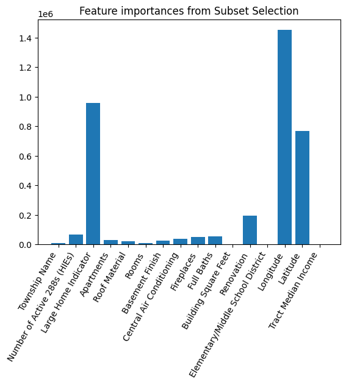

```python
importance = np.abs(lmodel.coef_)
features = sfs.get_feature_names_out()
plt.bar(height=importance, x=features)
plt.title("Feature importances from Subset Selection")
plt.xticks(rotation=60, ha = 'right')
plt.show()
```

### Ridge

```
43186778412.53171
207814.2882780963
```

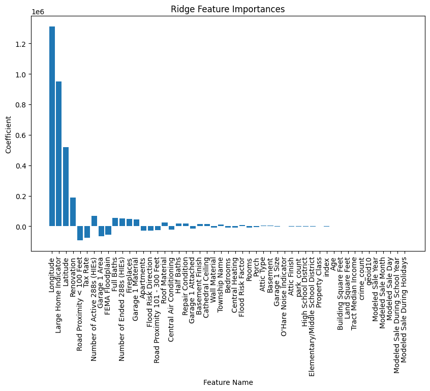

```python
lm2 = lm.Ridge(fit_intercept=True)
lm2.fit(X_train, y_train)
y_pred = lm2.predict(X_test)
mse = mean_squared_error(y_test, y_pred)
print(mse)
print(np.sqrt(mse))

feature_importances = lm2.coef_
feature_importances_dict = {col: coef for coef, col in zip(lm2.coef_, X_train.columns)}
sorted_importances = sorted(feature_importances_dict.items(), key=lambda x: abs(x[1]), reverse=True)
plt.figure(figsize=(10, 6))
plt.bar([x[0] for x in sorted_importances], [x[1] for x in sorted_importances])
plt.xlabel('Feature Name')
plt.ylabel('Coefficient')
plt.title('Ridge Feature Importances')
plt.xticks(rotation=90)
plt.show()
```

### Lasso

Lasso performs similar to both Ridge and Subset Selection, with Test MSE and indiviual error at $43193940787.81 and $207831.52 per house. Almost identically to Ridge, we see that: Longitude, Large Home Indicator, Latitude, Renovation, & Road Proximity being less than 100 Feet were the variables that affected the model most, we also see negative values being associated with the road proximity.

```
43193940787.80601
207831.52019798633
```

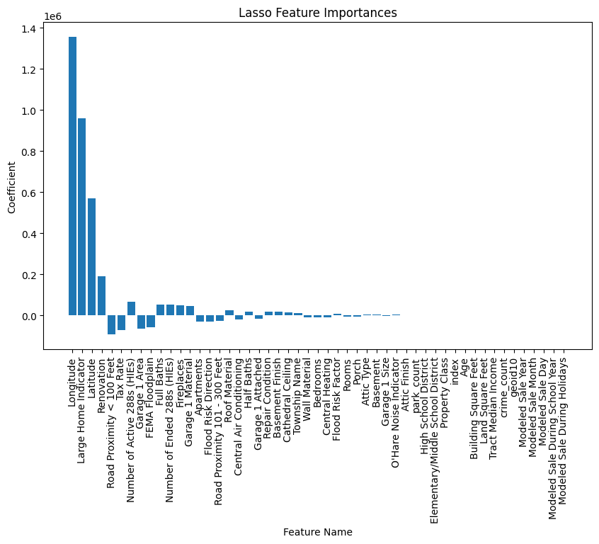

```python
lm3 = lm.Lasso(fit_intercept=True)
lm3.fit(X_train, y_train)
y_pred = lm3.predict(X_test)
mse = mean_squared_error(y_test, y_pred)
print(mse)
print(np.sqrt(mse))

feature_importances = lm3.coef_
feature_importances_dict = {col: coef for coef, col in zip(lm3.coef_, X_train.columns)}
sorted_importances = sorted(feature_importances_dict.items(), key=lambda x: abs(x[1]), reverse=True)
plt.figure(figsize=(10, 6))
plt.bar([x[0] for x in sorted_importances], [x[1] for x in sorted_importances])
plt.xlabel('Feature Name')
plt.ylabel('Coefficient')
plt.title('Lasso Feature Importances')
plt.xticks(rotation=90)
plt.show()
```

# Impact of neighborhood

We analyzed crime & park data in Chicago to see if there was any correlation as well. This is because:

- Crime can be a major factor affecting the price of homes. One of the main reasons is safety concerns. Potential buyers generally prefer to live in a safe neighborhood, and high crime rates can make an area feel unsafe. This can discourage people from buying homes in that neighborhood, leading to lower demand and, ultimately, lower prices.
- In addition to safety concerns, crime can also increase insurance costs. Home insurance companies typically charge higher premiums for properties located in high-crime areas. This can make it more expensive for homeowners to insure their properties, which can reduce their overall affordability and desirability.
- Crime can also result in property damage, such as broken windows or graffiti. This can lower the curb appeal of a home and reduce its value. The cost of repairing this damage can also be a factor that negatively affects home prices.
- High crime rates can create a negative perception of a neighborhood. Even if the crime rate is not particularly high, a negative perception of the area can still impact the price of homes. This negative perception can reduce demand and lower home prices

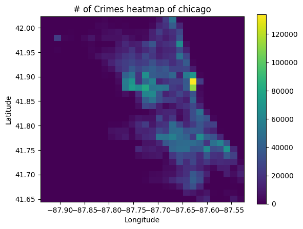

```python
df = crimes.dropna(subset=['Longitude', 'Latitude'])

heatmap, xedges, yedges = np.histogram2d(df.Longitude, df.Latitude, bins=30)
extent = [xedges[0], xedges[-1], yedges[0], yedges[-1]]
plt.clf()
plt.title("# of Crimes heatmap of chicago")
plt.xlabel("Longitude")
plt.ylabel("Latitude")
plt.imshow(heatmap.T, extent=extent, origin='lower')
plt.colorbar()
plt.show()
```

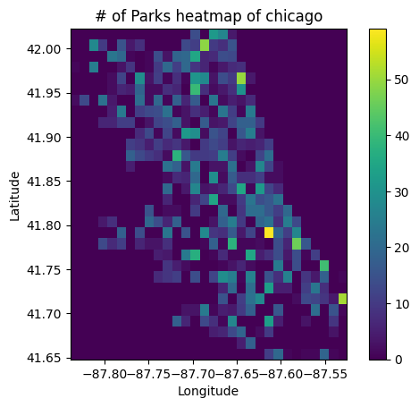

```python
df = parks.dropna(subset=['x_coord', 'y_coord'])
df.x_coord = df.x_coord.astype(float)
df.y_coord = df.y_coord.astype(float)
heatmap, xedges, yedges = np.histogram2d(df.x_coord, df.y_coord, bins=30)
extent = [xedges[0], xedges[-1], yedges[0], yedges[-1]]
plt.clf()
plt.title("# of Parks heatmap of chicago")
plt.imshow(heatmap.T, extent=extent, origin='lower')
plt.xlabel("Longitude")
plt.ylabel("Latitude")
plt.colorbar()
plt.show()
```

The number of parks in a neighborhood can be an important factor affecting the price of homes in the area. Having access to green spaces, such as parks, is desirable for many homebuyers, as they provide opportunities for recreation, relaxation, and social interaction. Thus, the availability and proximity of parks can contribute positively to the value of homes in the surrounding area.

Generally, homes located in neighborhoods with a higher number of parks tend to have higher property values than those in areas with fewer parks. This is because the presence of parks can enhance the quality of life for residents, which can increase demand for homes in the area. Additionally, proximity to parks can be a desirable feature for many homebuyers, particularly those with children or pets, which can also drive up home prices.

However, the relationship between the number of parks and home prices can vary depending on the location and type of parks. For example, parks that are well-maintained, have a variety of amenities, and are located within a reasonable distance of homes may have a greater positive impact on home prices than parks that are poorly maintained or located far away. Similarly, the presence of certain types of parks, such as those with sports facilities or walking trails, may be more desirable for some homebuyers than others, which can also affect home prices.

We see, like one might expect, that there is a significantly lower home prices in areas where the crime rate is much higher. The concentration of the prices is right at the bottom of the average house price -- unlike in areas where crime is much lower where we see a more typical distribution of home prices.

Somewhat more interestingly we see that as park count increases, the house price does not actually increase.

This could be because, the quality of the parks may be poor, which can offset any potential positive effects on home values. If the parks are poorly maintained or do not have desirable features, such as sports facilities or walking trails, they may not be attractive to homebuyers and may not contribute positively to home values.

Secondly, the location of the parks may not be ideal for homebuyers. If the parks are located far away from residential areas or in undesirable locations, such as near industrial sites or highways, they may not have a positive impact on home values.

Other factors may be more important in determining home values in the area. Like we have tested, access to good schools, proximity to public transportation, and low crime rates may be more significant factors in driving up home prices than the number of parks in the area.

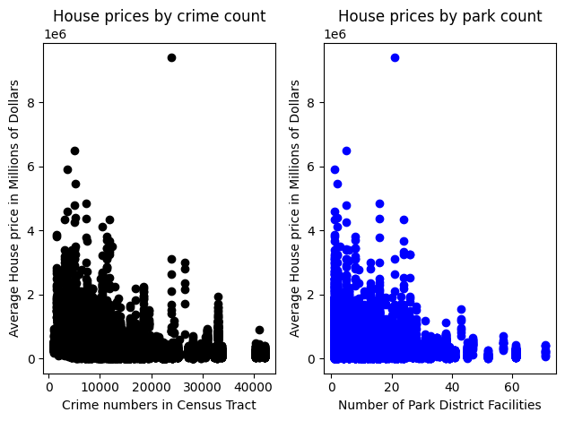

```python
plt.subplot(1, 2, 1)
plt.plot(housing['crime_count'], housing['Sale Price'], 'o', color='black')
plt.title('House prices by crime count')
plt.xlabel('Crime numbers in Census Tract')
plt.ylabel('Average House price in Millions of Dollars')
plt.subplot(1, 2, 2)
plt.plot(housing['park_count'], housing['Sale Price'], 'o', color='blue')
plt.title('House prices by park count')
plt.xlabel('Number of Park District Facilities')
plt.ylabel('Average House price in Millions of Dollars')
plt.tight_layout()
plt.show()
```

# Conclusion

In our research, we compared three machine learning models - Linear Regression with subset selection, Ridge Regression, and Lasso Regression - to predict housing prices in Chicago. Each model incorporated a wide range of variables, including crime rates, park proximity, and other factors influencing home values. The Ridge Regression model provided the best performance with a Test MSE of $43186778412.53 and an individual error of $207814.288 per house. In contrast, Linear Regression with subset selection had a Test MSE of $44440433153.70373 and an individual error of $210809.00, while Lasso Regression had a Test MSE of $43193940787.80 and an individual error of $207831.52 per house.

The relatively high errors observed in all three models could be attributed to several factors. Firstly, the large number of variables included in the models might have introduced multicollinearity or increased complexity, making it difficult for the models to discern the true underlying relationships between the variables and housing prices. Secondly, there may be potential influential outliers or noise in the data, which can adversely affect the model's predictive accuracy. Lastly, the models we used might not be able to fully capture the complex, nonlinear relationships between housing prices and the predictors, resulting in high errors.

To improve the performance of our models, we could consider exploring other machine learning techniques that can better handle complex relationships and high-dimensional data. Some potential models include:

Decision Trees and Random Forests: These models can handle nonlinear relationships and interactions between variables, which might help to capture the complex patterns in the data. Random Forests, in particular, can provide a more robust and accurate model by aggregating the predictions of multiple Decision Trees.

Gradient Boosting Machines (GBM): GBMs are a powerful ensemble technique that builds a strong model by iteratively adding weak models, usually decision trees, to the ensemble. GBMs can handle complex interactions and nonlinearities in the data and often provide better predictive accuracy compared to single models.

Support Vector Machines (SVM) with a nonlinear kernel: SVMs can be used for regression tasks, and by using a nonlinear kernel, such as the Radial Basis Function (RBF) kernel, they can effectively capture complex, nonlinear relationships in the data.

Neural Networks: Deep learning techniques, such as neural networks, can model highly complex relationships between variables and are especially suited for handling large and high-dimensional datasets. However, they require careful tuning and can be computationally expensive.

Before applying these alternative models, it is essential to address any data quality issues, such as outliers or noise, that might be contributing to the high errors. A major failing of our research and project was to produce a dataset of consistent and reliable data -- our work was significantly hampered by constant issues with the data not fitting proprly, or having NA values for many of the columns we had.

Additionally, feature engineering techniques, such as dimensionality reduction or feature selection, can be employed to reduce the number of variables in the models and potentially enhance their performance. By exploring these alternative models and refining our dataset, we could potentially achieve more accurate predictions of housing prices in Chicago.

Furthermore, our exploration of crime rates and park proximity unveiled some interesting insights. As expected, areas with higher crime rates exhibited significantly lower home prices, demonstrating the impact of safety concerns on housing values. However, the number of parks in a neighborhood did not have a clear positive relationship with home prices. This could be attributed to various factors, such as park quality, location, or other more significant determinants of home values like access to good schools, proximity to public transportation, and low crime rates.

By incorporating these factors into our machine learning model, we were able to gain a more comprehensive understanding of housing values in Chicago. Our study also responded to the call for home valuation methodologies that move beyond racially biased appraisal practices and consider actual determinants of housing quality and safety. The findings of this research not only contribute to the existing literature on housing price prediction but also serve as a valuable resource for policymakers, real estate professionals, and homeowners in understanding the complex interplay of factors that shape housing values in urban areas.

### References

Chicago Police Department. (2023, April 27). Crimes - 2001 to present | City of Chicago | Data Portal. City of Chicago | Data Portal | City of Chicago | Data Portal. https://data.cityofchicago.org/Public-Safety/Crimes-2001-to-Present/ijzp-q8t2

Cook County Assessor's Office. (2022, May 11). Assessor [Archived 05-11-2022] - Residential modeling characteristics (Chicago) | Cook County open data. Cook County Open Data. https://datacatalog.cookcountyil.gov/Property-Taxation/Assessor-Archived-05-11-2022-Residential-Modeling-/8f9d-wy2d

Historical Redlining Is Associated with Present-Day Air Pollution Disparities in U.S. Cities Haley M. Lane, Rachel Morello-Frosch, Julian D. Marshall, and Joshua S. Apte Environmental Science & Technology Letters 2022 9 (4), 345-350 DOI: 10.1021/acs.estlett.1c01012

Prodosh E. Simlai. 2021. Predicting owner-occupied housing values using machine learning: an empirical investigation of California census tracts data. Journal of Property Research

Bloomberg. "Chicago Plans to Speed Up Vacant Lot Sales in Bid to Curb Crime." Bloomberg News, 18 Oct. 2022, https://www.bloomberg.com/news/articles/2022-10-18/chicago-plans-to-speed-up-vacant-lot-sales-in-bid-to-curb-crime

"Redlining's Legacy: Racism and Air Pollution." The New York Times, 9 Mar. 2022, www.nytimes.com/2022/03/09/climate/redlining-racism-air-pollution.html.

"Black Homeowners Face Bias in Appraisals." The New York Times, 2 Nov. 2022, www.nytimes.com/2022/11/02/realestate/racial-bias-home-appraisals.html.

Shaikh, M. Shamim. "Environmental Sustainability and Islamic Identity." Federal Reserve Bank of Atlanta, 2011, www.atlantafed.org/-/media/Documents/news/conferences/2011/green-foundation/shaikh.pdf.